# Risk Factor Analysis

## Outcome Variable

**Outcome Variable:** haz

## Predictor Variables

**Intervention Variable:** exclfeed36

**Adjustment Set:**

- arm
- sex
- brthmon
- W_mage
- meducyrs
- feducyrs
- hhwealth_quart
- hfoodsec
- W_mhtcm
- W_mwtkg
- W_mbmi
- vagbrth
- W_gagebrth
- W_birthwt
- W_birthlen
- W_nrooms
- W_nchldlt5
- month
- W_parity
- impfloor
- impsan
- safeh20
- delta_W_mage
- delta_meducyrs
- delta_feducyrs
- delta_hhwealth_quart
- delta_hfoodsec
- delta_W_mhtcm
- delta_W_mwtkg
- delta_W_mbmi
- delta_vagbrth
- delta_W_gagebrth
- delta_W_birthwt
- delta_W_birthlen
- delta_W_nrooms
- delta_W_nchldlt5
- delta_month
- delta_W_parity
- delta_impfloor
- delta_impsan
- delta_safeh20

## Stratifying Variables

The analysis was stratified on these variable(s):

- agecat
- studyid
- country

## Data Summary

| agecat | studyid | country | exclfeed36 | n_cell | n | outcome_variable |
| --- | --- | --- | --- | --- | --- | --- |
| Birth | CMC-V-BCS-2002 | INDIA | 1 | 3 | 3 | haz |
| Birth | CMC-V-BCS-2002 | INDIA | 0 | 0 | 3 | haz |
| Birth | EE | PAKISTAN | 1 | 3 | 7 | haz |
| Birth | EE | PAKISTAN | 0 | 4 | 7 | haz |
| Birth | GMS-Nepal | NEPAL | 1 | 422 | 526 | haz |
| Birth | GMS-Nepal | NEPAL | 0 | 104 | 526 | haz |
| Birth | IRC | INDIA | 1 | 0 | 4 | haz |
| Birth | IRC | INDIA | 0 | 4 | 4 | haz |
| Birth | JiVitA-3 | BANGLADESH | 1 | 8322 | 10681 | haz |
| Birth | JiVitA-3 | BANGLADESH | 0 | 2359 | 10681 | haz |
| Birth | JiVitA-4 | BANGLADESH | 1 | 1994 | 2517 | haz |
| Birth | JiVitA-4 | BANGLADESH | 0 | 523 | 2517 | haz |
| Birth | Keneba | GAMBIA | 1 | 363 | 1253 | haz |
| Birth | Keneba | GAMBIA | 0 | 890 | 1253 | haz |
| Birth | MAL-ED | BANGLADESH | 1 | 32 | 221 | haz |
| Birth | MAL-ED | BANGLADESH | 0 | 189 | 221 | haz |
| Birth | MAL-ED | BRAZIL | 1 | 5 | 65 | haz |
| Birth | MAL-ED | BRAZIL | 0 | 60 | 65 | haz |
| Birth | MAL-ED | INDIA | 1 | 1 | 42 | haz |
| Birth | MAL-ED | INDIA | 0 | 41 | 42 | haz |
| Birth | MAL-ED | NEPAL | 1 | 0 | 26 | haz |
| Birth | MAL-ED | NEPAL | 0 | 26 | 26 | haz |
| Birth | MAL-ED | PERU | 1 | 5 | 223 | haz |
| Birth | MAL-ED | PERU | 0 | 218 | 223 | haz |
| Birth | MAL-ED | SOUTH AFRICA | 1 | 1 | 105 | haz |
| Birth | MAL-ED | SOUTH AFRICA | 0 | 104 | 105 | haz |
| Birth | MAL-ED | TANZANIA, UNITED REPUBLIC OF | 1 | 0 | 119 | haz |
| Birth | MAL-ED | TANZANIA, UNITED REPUBLIC OF | 0 | 119 | 119 | haz |
| Birth | PROVIDE | BANGLADESH | 1 | 119 | 490 | haz |
| Birth | PROVIDE | BANGLADESH | 0 | 371 | 490 | haz |

[output cut: 66 more lines]

The following strata were considered:

- agecat: 24 months, studyid: CMC-V-BCS-2002, country: INDIA
- agecat: 24 months, studyid: EE, country: PAKISTAN
- agecat: 24 months, studyid: GMS-Nepal, country: NEPAL
- agecat: 24 months, studyid: IRC, country: INDIA
- agecat: 24 months, studyid: JiVitA-3, country: BANGLADESH
- agecat: 24 months, studyid: JiVitA-4, country: BANGLADESH
- agecat: 24 months, studyid: Keneba, country: GAMBIA
- agecat: 24 months, studyid: LCNI-5, country: MALAWI
- agecat: 24 months, studyid: MAL-ED, country: BANGLADESH
- agecat: 24 months, studyid: MAL-ED, country: BRAZIL
- agecat: 24 months, studyid: MAL-ED, country: INDIA
- agecat: 24 months, studyid: MAL-ED, country: NEPAL
- agecat: 24 months, studyid: MAL-ED, country: PERU
- agecat: 24 months, studyid: MAL-ED, country: SOUTH AFRICA
- agecat: 24 months, studyid: MAL-ED, country: TANZANIA, UNITED REPUBLIC OF
- agecat: 24 months, studyid: PROVIDE, country: BANGLADESH
- agecat: 6 months, studyid: CMC-V-BCS-2002, country: INDIA
- agecat: 6 months, studyid: EE, country: PAKISTAN
- agecat: 6 months, studyid: GMS-Nepal, country: NEPAL
- agecat: 6 months, studyid: IRC, country: INDIA
- agecat: 6 months, studyid: JiVitA-3, country: BANGLADESH
- agecat: 6 months, studyid: JiVitA-4, country: BANGLADESH
- agecat: 6 months, studyid: Keneba, country: GAMBIA
- agecat: 6 months, studyid: LCNI-5, country: MALAWI
- agecat: 6 months, studyid: MAL-ED, country: BANGLADESH
- agecat: 6 months, studyid: MAL-ED, country: BRAZIL
- agecat: 6 months, studyid: MAL-ED, country: INDIA
- agecat: 6 months, studyid: MAL-ED, country: NEPAL
- agecat: 6 months, studyid: MAL-ED, country: PERU
- agecat: 6 months, studyid: MAL-ED, country: SOUTH AFRICA
- agecat: 6 months, studyid: MAL-ED, country: TANZANIA, UNITED REPUBLIC OF
- agecat: 6 months, studyid: PROVIDE, country: BANGLADESH
- agecat: 6 months, studyid: SAS-FoodSuppl, country: INDIA
- agecat: Birth, studyid: CMC-V-BCS-2002, country: INDIA
- agecat: Birth, studyid: EE, country: PAKISTAN
- agecat: Birth, studyid: GMS-Nepal, country: NEPAL
- agecat: Birth, studyid: IRC, country: INDIA
- agecat: Birth, studyid: JiVitA-3, country: BANGLADESH
- agecat: Birth, studyid: JiVitA-4, country: BANGLADESH
- agecat: Birth, studyid: Keneba, country: GAMBIA
- agecat: Birth, studyid: MAL-ED, country: BANGLADESH
- agecat: Birth, studyid: MAL-ED, country: BRAZIL
- agecat: Birth, studyid: MAL-ED, country: INDIA
- agecat: Birth, studyid: MAL-ED, country: NEPAL
- agecat: Birth, studyid: MAL-ED, country: PERU
- agecat: Birth, studyid: MAL-ED, country: SOUTH AFRICA
- agecat: Birth, studyid: MAL-ED, country: TANZANIA, UNITED REPUBLIC OF
- agecat: Birth, studyid: PROVIDE, country: BANGLADESH

### Dropped Strata

Some strata were dropped due to rare outcomes:

- agecat: Birth, studyid: CMC-V-BCS-2002, country: INDIA
- agecat: Birth, studyid: EE, country: PAKISTAN
- agecat: Birth, studyid: IRC, country: INDIA
- agecat: Birth, studyid: MAL-ED, country: INDIA
- agecat: Birth, studyid: MAL-ED, country: NEPAL
- agecat: Birth, studyid: MAL-ED, country: SOUTH AFRICA
- agecat: Birth, studyid: MAL-ED, country: TANZANIA, UNITED REPUBLIC OF
- agecat: 6 months, studyid: CMC-V-BCS-2002, country: INDIA
- agecat: 6 months, studyid: EE, country: PAKISTAN
- agecat: 6 months, studyid: IRC, country: INDIA
- agecat: 6 months, studyid: MAL-ED, country: NEPAL
- agecat: 6 months, studyid: MAL-ED, country: SOUTH AFRICA
- agecat: 6 months, studyid: MAL-ED, country: TANZANIA, UNITED REPUBLIC OF
- agecat: 6 months, studyid: SAS-FoodSuppl, country: INDIA
- agecat: 24 months, studyid: CMC-V-BCS-2002, country: INDIA
- agecat: 24 months, studyid: EE, country: PAKISTAN
- agecat: 24 months, studyid: IRC, country: INDIA
- agecat: 24 months, studyid: MAL-ED, country: NEPAL
- agecat: 24 months, studyid: MAL-ED, country: PERU
- agecat: 24 months, studyid: MAL-ED, country: SOUTH AFRICA
- agecat: 24 months, studyid: MAL-ED, country: TANZANIA, UNITED REPUBLIC OF

## Methods Detail

We’re interested in the causal parameters $E[Y_a]$ for all values of $a \in \mathcal{A}$. These parameters represent the mean outcome if, possibly contrary to fact, we intervened to set all units to have $A=a$. Under the randomization and positivity assumptions, these are identified by the statistical parameters $\psi_a=E_W[E_{Y|A,W}(Y|A=a,W)]$. In addition, we’re interested in the mean of $Y$, $E[Y]$ under no intervention (the observed mean). We will estimate these parameters by using SuperLearner to fit the relevant likelihood factors – $E_{Y|A,W}(Y|A=a,W)$ and $p(A=a|W)$, and then updating our likelihood fit using a joint TMLE.

For unadjusted analyses ($W=\{\}$), initial likelihoods were estimated using Lrnr_glm to estimate the simple $E(Y|A)$ and Lrnr_mean to estimate $p(A)$. For adjusted analyses, a small library containing Lrnr_glmnet, Lrnr_xgboost, and Lrnr_mean was used.

Having estimated these parameters, we will then use the delta method to estimate relative risks and attributable risks relative to a prespecified baseline level of $A$.

# Results Detail

## Results Plots

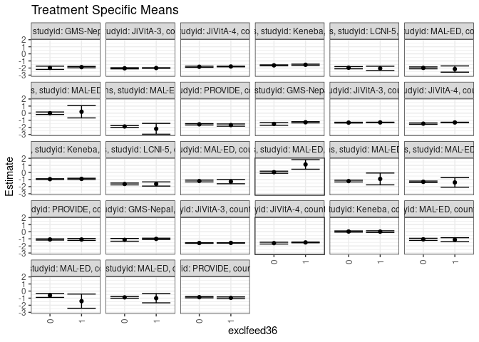

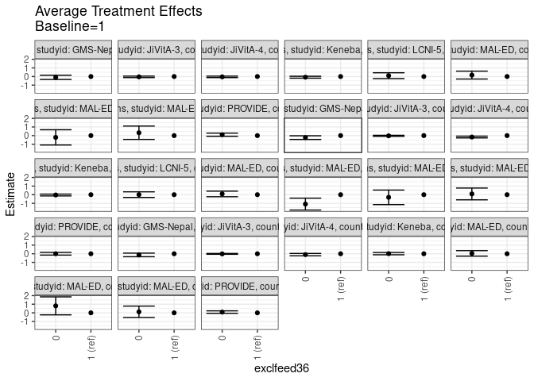

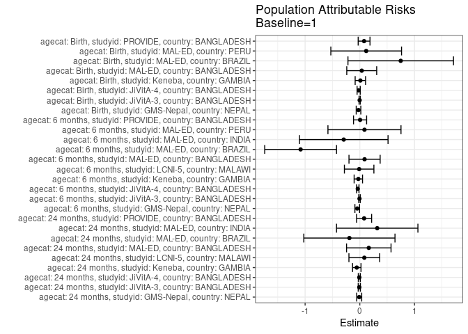

## Results Table

### Parameter: TSM

| agecat | studyid | country | intervention_level | baseline_level | estimate | ci_lower | ci_upper |
| --- | --- | --- | --- | --- | --- | --- | --- |
| Birth | GMS-Nepal | NEPAL | 1 | NA | -1.0062649 | -1.1022686 | -0.9102612 |
| Birth | GMS-Nepal | NEPAL | 0 | NA | -1.1408507 | -1.3340557 | -0.9476458 |
| Birth | JiVitA-3 | BANGLADESH | 1 | NA | -1.5732179 | -1.6012398 | -1.5451961 |
| Birth | JiVitA-3 | BANGLADESH | 0 | NA | -1.5870328 | -1.6319393 | -1.5421264 |
| Birth | JiVitA-4 | BANGLADESH | 1 | NA | -1.5024093 | -1.5556152 | -1.4492034 |
| Birth | JiVitA-4 | BANGLADESH | 0 | NA | -1.6036710 | -1.7305026 | -1.4768393 |
| Birth | Keneba | GAMBIA | 1 | NA | 0.0216079 | -0.0972524 | 0.1404682 |
| Birth | Keneba | GAMBIA | 0 | NA | 0.0357908 | -0.0451665 | 0.1167481 |
| Birth | MAL-ED | BANGLADESH | 1 | NA | -1.1154578 | -1.3940171 | -0.8368984 |
| Birth | MAL-ED | BANGLADESH | 0 | NA | -1.0698506 | -1.2215201 | -0.9181812 |
| Birth | MAL-ED | BRAZIL | 1 | NA | -1.4240000 | -2.4288338 | -0.4191662 |
| Birth | MAL-ED | BRAZIL | 0 | NA | -0.6136667 | -0.8950902 | -0.3322431 |
| Birth | MAL-ED | PERU | 1 | NA | -1.0080000 | -1.6595862 | -0.3564138 |
| Birth | MAL-ED | PERU | 0 | NA | -0.8886239 | -1.0108291 | -0.7664186 |
| Birth | PROVIDE | BANGLADESH | 1 | NA | -0.9550648 | -1.0842999 | -0.8258296 |
| Birth | PROVIDE | BANGLADESH | 0 | NA | -0.8662615 | -0.9541803 | -0.7783427 |
| 6 months | GMS-Nepal | NEPAL | 1 | NA | -1.2868150 | -1.3738066 | -1.1998233 |
| 6 months | GMS-Nepal | NEPAL | 0 | NA | -1.5199414 | -1.7122960 | -1.3275867 |
| 6 months | JiVitA-3 | BANGLADESH | 1 | NA | -1.3093063 | -1.3412949 | -1.2773177 |
| 6 months | JiVitA-3 | BANGLADESH | 0 | NA | -1.3354191 | -1.3899678 | -1.2808704 |
| 6 months | JiVitA-4 | BANGLADESH | 1 | NA | -1.3140832 | -1.3550393 | -1.2731272 |
| 6 months | JiVitA-4 | BANGLADESH | 0 | NA | -1.4793674 | -1.5735298 | -1.3852051 |
| 6 months | Keneba | GAMBIA | 1 | NA | -0.9085693 | -0.9986836 | -0.8184551 |
| 6 months | Keneba | GAMBIA | 0 | NA | -0.9440439 | -1.0037932 | -0.8842947 |
| 6 months | LCNI-5 | MALAWI | 1 | NA | -1.6275102 | -1.9232434 | -1.3317769 |
| 6 months | LCNI-5 | MALAWI | 0 | NA | -1.6230946 | -1.7544372 | -1.4917521 |
| 6 months | MAL-ED | BANGLADESH | 1 | NA | -1.2942841 | -1.5929764 | -0.9955917 |
| 6 months | MAL-ED | BANGLADESH | 0 | NA | -1.2068040 | -1.3338242 | -1.0797839 |
| 6 months | MAL-ED | BRAZIL | 1 | NA | 1.1301050 | 0.4592466 | 1.8009634 |
| 6 months | MAL-ED | BRAZIL | 0 | NA | 0.0371961 | -0.1082972 | 0.1826893 |
| 6 months | MAL-ED | INDIA | 1 | NA | -0.9116667 | -1.7458275 | -0.0775058 |
| 6 months | MAL-ED | INDIA | 0 | NA | -1.2173884 | -1.3368172 | -1.0979596 |
| 6 months | MAL-ED | PERU | 1 | NA | -1.4083333 | -2.0844008 | -0.7322659 |
| 6 months | MAL-ED | PERU | 0 | NA | -1.3211685 | -1.4309807 | -1.2113564 |
| 6 months | PROVIDE | BANGLADESH | 1 | NA | -1.0904365 | -1.2235609 | -0.9573122 |
| 6 months | PROVIDE | BANGLADESH | 0 | NA | -1.0867559 | -1.1733596 | -1.0001521 |
| 24 months | GMS-Nepal | NEPAL | 1 | NA | -1.8721530 | -1.9658124 | -1.7784935 |
| 24 months | GMS-Nepal | NEPAL | 0 | NA | -1.9682090 | -2.1957096 | -1.7407083 |
| 24 months | JiVitA-3 | BANGLADESH | 1 | NA | -1.9978537 | -2.0403127 | -1.9553947 |
| 24 months | JiVitA-3 | BANGLADESH | 0 | NA | -2.0356027 | -2.1131910 | -1.9580145 |
| 24 months | JiVitA-4 | BANGLADESH | 1 | NA | -1.7833174 | -1.8259924 | -1.7406423 |
| 24 months | JiVitA-4 | BANGLADESH | 0 | NA | -1.8198567 | -1.8988203 | -1.7408930 |
| 24 months | Keneba | GAMBIA | 1 | NA | -1.5426793 | -1.6331603 | -1.4521983 |
| 24 months | Keneba | GAMBIA | 0 | NA | -1.6216934 | -1.6888921 | -1.5544946 |
| 24 months | LCNI-5 | MALAWI | 1 | NA | -2.0475749 | -2.3492527 | -1.7458970 |
| 24 months | LCNI-5 | MALAWI | 0 | NA | -1.9515785 | -2.1101825 | -1.7929746 |
| 24 months | MAL-ED | BANGLADESH | 1 | NA | -2.1426733 | -2.5823753 | -1.7029714 |
| 24 months | MAL-ED | BANGLADESH | 0 | NA | -1.9759411 | -2.1076063 | -1.8442760 |
| 24 months | MAL-ED | BRAZIL | 1 | NA | 0.1965286 | -0.6699078 | 1.0629650 |
| 24 months | MAL-ED | BRAZIL | 0 | NA | -0.0086619 | -0.1813216 | 0.1639978 |
| 24 months | MAL-ED | INDIA | 1 | NA | -2.2088889 | -2.9737293 | -1.4440485 |
| 24 months | MAL-ED | INDIA | 0 | NA | -1.8773023 | -2.0042653 | -1.7503393 |
| 24 months | PROVIDE | BANGLADESH | 1 | NA | -1.6806789 | -1.8394521 | -1.5219056 |
| 24 months | PROVIDE | BANGLADESH | 0 | NA | -1.5741902 | -1.6697732 | -1.4786072 |

### Parameter: E(Y)

| agecat | studyid | country | intervention_level | baseline_level | estimate | ci_lower | ci_upper |
| --- | --- | --- | --- | --- | --- | --- | --- |
| Birth | GMS-Nepal | NEPAL | NA | NA | -1.0299620 | -1.1192344 | -0.9406896 |
| Birth | JiVitA-3 | BANGLADESH | NA | NA | -1.5762700 | -1.6018685 | -1.5506716 |
| Birth | JiVitA-4 | BANGLADESH | NA | NA | -1.5234724 | -1.5733491 | -1.4735957 |
| Birth | Keneba | GAMBIA | NA | NA | 0.0318156 | -0.0392907 | 0.1029220 |
| Birth | MAL-ED | BANGLADESH | NA | NA | -1.0802262 | -1.2151319 | -0.9453206 |
| Birth | MAL-ED | BRAZIL | NA | NA | -0.6760000 | -0.9521457 | -0.3998543 |
| Birth | MAL-ED | PERU | NA | NA | -0.8913004 | -1.0115814 | -0.7710195 |
| Birth | PROVIDE | BANGLADESH | NA | NA | -0.8769592 | -0.9559693 | -0.7979491 |
| 6 months | GMS-Nepal | NEPAL | NA | NA | -1.3337634 | -1.4135810 | -1.2539459 |
| 6 months | JiVitA-3 | BANGLADESH | NA | NA | -1.3152982 | -1.3444394 | -1.2861570 |
| 6 months | JiVitA-4 | BANGLADESH | NA | NA | -1.3514886 | -1.3904044 | -1.3125729 |
| 6 months | Keneba | GAMBIA | NA | NA | -0.9355822 | -0.9858754 | -0.8852889 |
| 6 months | LCNI-5 | MALAWI | NA | NA | -1.6395956 | -1.7592633 | -1.5199278 |
| 6 months | MAL-ED | BANGLADESH | NA | NA | -1.2072639 | -1.3248889 | -1.0896388 |
| 6 months | MAL-ED | BRAZIL | NA | NA | 0.0475758 | -0.0963508 | 0.1915023 |
| 6 months | MAL-ED | INDIA | NA | NA | -1.2055794 | -1.3250712 | -1.0860876 |
| 6 months | MAL-ED | PERU | NA | NA | -1.3230913 | -1.4314947 | -1.2146879 |
| 6 months | PROVIDE | BANGLADESH | NA | NA | -1.0855583 | -1.1591292 | -1.0119875 |
| 24 months | GMS-Nepal | NEPAL | NA | NA | -1.8830717 | -1.9710591 | -1.7950844 |
| 24 months | JiVitA-3 | BANGLADESH | NA | NA | -2.0071989 | -2.0453355 | -1.9690623 |
| 24 months | JiVitA-4 | BANGLADESH | NA | NA | -1.7922845 | -1.8313538 | -1.7532153 |
| 24 months | Keneba | GAMBIA | NA | NA | -1.5981956 | -1.6534947 | -1.5428965 |
| 24 months | LCNI-5 | MALAWI | NA | NA | -1.9651323 | -2.1053230 | -1.8249415 |
| 24 months | MAL-ED | BANGLADESH | NA | NA | -1.9783962 | -2.1050210 | -1.8517715 |
| 24 months | MAL-ED | BRAZIL | NA | NA | 0.0061144 | -0.1625850 | 0.1748138 |
| 24 months | MAL-ED | INDIA | NA | NA | -1.8906250 | -2.0165920 | -1.7646580 |
| 24 months | PROVIDE | BANGLADESH | NA | NA | -1.6022704 | -1.6857342 | -1.5188065 |

### Parameter: ATE

| agecat | studyid | country | intervention_level | baseline_level | estimate | ci_lower | ci_upper |
| --- | --- | --- | --- | --- | --- | --- | --- |
| Birth | GMS-Nepal | NEPAL | 1 | 1 | 0.0000000 | 0.0000000 | 0.0000000 |
| Birth | GMS-Nepal | NEPAL | 0 | 1 | -0.1345858 | -0.3427865 | 0.0736148 |
| Birth | JiVitA-3 | BANGLADESH | 1 | 1 | 0.0000000 | 0.0000000 | 0.0000000 |
| Birth | JiVitA-3 | BANGLADESH | 0 | 1 | -0.0138149 | -0.0621185 | 0.0344888 |
| Birth | JiVitA-4 | BANGLADESH | 1 | 1 | 0.0000000 | 0.0000000 | 0.0000000 |
| Birth | JiVitA-4 | BANGLADESH | 0 | 1 | -0.1012617 | -0.2382841 | 0.0357608 |
| Birth | Keneba | GAMBIA | 1 | 1 | 0.0000000 | 0.0000000 | 0.0000000 |
| Birth | Keneba | GAMBIA | 0 | 1 | 0.0141829 | -0.1190806 | 0.1474464 |
| Birth | MAL-ED | BANGLADESH | 1 | 1 | 0.0000000 | 0.0000000 | 0.0000000 |
| Birth | MAL-ED | BANGLADESH | 0 | 1 | 0.0456071 | -0.2726843 | 0.3638986 |
| Birth | MAL-ED | BRAZIL | 1 | 1 | 0.0000000 | 0.0000000 | 0.0000000 |
| Birth | MAL-ED | BRAZIL | 0 | 1 | 0.8103333 | -0.2331657 | 1.8538323 |
| Birth | MAL-ED | PERU | 1 | 1 | 0.0000000 | 0.0000000 | 0.0000000 |
| Birth | MAL-ED | PERU | 0 | 1 | 0.1193761 | -0.5435709 | 0.7823232 |
| Birth | PROVIDE | BANGLADESH | 1 | 1 | 0.0000000 | 0.0000000 | 0.0000000 |
| Birth | PROVIDE | BANGLADESH | 0 | 1 | 0.0888033 | -0.0534903 | 0.2310968 |
| 6 months | GMS-Nepal | NEPAL | 1 | 1 | 0.0000000 | 0.0000000 | 0.0000000 |
| 6 months | GMS-Nepal | NEPAL | 0 | 1 | -0.2331264 | -0.4444202 | -0.0218326 |
| 6 months | JiVitA-3 | BANGLADESH | 1 | 1 | 0.0000000 | 0.0000000 | 0.0000000 |
| 6 months | JiVitA-3 | BANGLADESH | 0 | 1 | -0.0261128 | -0.0854187 | 0.0331931 |
| 6 months | JiVitA-4 | BANGLADESH | 1 | 1 | 0.0000000 | 0.0000000 | 0.0000000 |
| 6 months | JiVitA-4 | BANGLADESH | 0 | 1 | -0.1652842 | -0.2665899 | -0.0639785 |
| 6 months | Keneba | GAMBIA | 1 | 1 | 0.0000000 | 0.0000000 | 0.0000000 |
| 6 months | Keneba | GAMBIA | 0 | 1 | -0.0354746 | -0.1424334 | 0.0714843 |
| 6 months | LCNI-5 | MALAWI | 1 | 1 | 0.0000000 | 0.0000000 | 0.0000000 |
| 6 months | LCNI-5 | MALAWI | 0 | 1 | 0.0044156 | -0.3188754 | 0.3277066 |
| 6 months | MAL-ED | BANGLADESH | 1 | 1 | 0.0000000 | 0.0000000 | 0.0000000 |
| 6 months | MAL-ED | BANGLADESH | 0 | 1 | 0.0874800 | -0.2375384 | 0.4124985 |
| 6 months | MAL-ED | BRAZIL | 1 | 1 | 0.0000000 | 0.0000000 | 0.0000000 |
| 6 months | MAL-ED | BRAZIL | 0 | 1 | -1.0929090 | -1.7838714 | -0.4019466 |
| 6 months | MAL-ED | INDIA | 1 | 1 | 0.0000000 | 0.0000000 | 0.0000000 |
| 6 months | MAL-ED | INDIA | 0 | 1 | -0.3057217 | -1.1483886 | 0.5369452 |
| 6 months | MAL-ED | PERU | 1 | 1 | 0.0000000 | 0.0000000 | 0.0000000 |
| 6 months | MAL-ED | PERU | 0 | 1 | 0.0871648 | -0.5977629 | 0.7720924 |
| 6 months | PROVIDE | BANGLADESH | 1 | 1 | 0.0000000 | 0.0000000 | 0.0000000 |
| 6 months | PROVIDE | BANGLADESH | 0 | 1 | 0.0036807 | -0.1538218 | 0.1611831 |
| 24 months | GMS-Nepal | NEPAL | 1 | 1 | 0.0000000 | 0.0000000 | 0.0000000 |
| 24 months | GMS-Nepal | NEPAL | 0 | 1 | -0.0960560 | -0.3406375 | 0.1485255 |
| 24 months | JiVitA-3 | BANGLADESH | 1 | 1 | 0.0000000 | 0.0000000 | 0.0000000 |
| 24 months | JiVitA-3 | BANGLADESH | 0 | 1 | -0.0377491 | -0.1239465 | 0.0484484 |
| 24 months | JiVitA-4 | BANGLADESH | 1 | 1 | 0.0000000 | 0.0000000 | 0.0000000 |
| 24 months | JiVitA-4 | BANGLADESH | 0 | 1 | -0.0365393 | -0.1218549 | 0.0487763 |
| 24 months | Keneba | GAMBIA | 1 | 1 | 0.0000000 | 0.0000000 | 0.0000000 |
| 24 months | Keneba | GAMBIA | 0 | 1 | -0.0790141 | -0.1897204 | 0.0316923 |
| 24 months | LCNI-5 | MALAWI | 1 | 1 | 0.0000000 | 0.0000000 | 0.0000000 |
| 24 months | LCNI-5 | MALAWI | 0 | 1 | 0.0959963 | -0.2457306 | 0.4377232 |
| 24 months | MAL-ED | BANGLADESH | 1 | 1 | 0.0000000 | 0.0000000 | 0.0000000 |
| 24 months | MAL-ED | BANGLADESH | 0 | 1 | 0.1667322 | -0.2918519 | 0.6253163 |
| 24 months | MAL-ED | BRAZIL | 1 | 1 | 0.0000000 | 0.0000000 | 0.0000000 |
| 24 months | MAL-ED | BRAZIL | 0 | 1 | -0.2051905 | -1.0890165 | 0.6786356 |
| 24 months | MAL-ED | INDIA | 1 | 1 | 0.0000000 | 0.0000000 | 0.0000000 |
| 24 months | MAL-ED | INDIA | 0 | 1 | 0.3315866 | -0.4437201 | 1.1068933 |
| 24 months | PROVIDE | BANGLADESH | 1 | 1 | 0.0000000 | 0.0000000 | 0.0000000 |
| 24 months | PROVIDE | BANGLADESH | 0 | 1 | 0.1064887 | -0.0753826 | 0.2883600 |

### Parameter: PAR

| agecat | studyid | country | intervention_level | baseline_level | estimate | ci_lower | ci_upper |
| --- | --- | --- | --- | --- | --- | --- | --- |
| Birth | GMS-Nepal | NEPAL | 1 | NA | -0.0236971 | -0.0657400 | 0.0183458 |
| Birth | JiVitA-3 | BANGLADESH | 1 | NA | -0.0030521 | -0.0137070 | 0.0076029 |
| Birth | JiVitA-4 | BANGLADESH | 1 | NA | -0.0210631 | -0.0498526 | 0.0077264 |
| Birth | Keneba | GAMBIA | 1 | NA | 0.0102078 | -0.0850032 | 0.1054188 |
| Birth | MAL-ED | BANGLADESH | 1 | NA | 0.0352315 | -0.2383498 | 0.3088128 |
| Birth | MAL-ED | BRAZIL | 1 | NA | 0.7480000 | -0.2166815 | 1.7126815 |
| Birth | MAL-ED | PERU | 1 | NA | 0.1166996 | -0.5296780 | 0.7630771 |
| Birth | PROVIDE | BANGLADESH | 1 | NA | 0.0781056 | -0.0298669 | 0.1860781 |
| 6 months | GMS-Nepal | NEPAL | 1 | NA | -0.0469485 | -0.0897173 | -0.0041797 |
| 6 months | JiVitA-3 | BANGLADESH | 1 | NA | -0.0059919 | -0.0196655 | 0.0076817 |
| 6 months | JiVitA-4 | BANGLADESH | 1 | NA | -0.0374054 | -0.0593938 | -0.0154170 |
| 6 months | Keneba | GAMBIA | 1 | NA | -0.0270128 | -0.1038394 | 0.0498137 |
| 6 months | LCNI-5 | MALAWI | 1 | NA | -0.0120854 | -0.2817160 | 0.2575453 |
| 6 months | MAL-ED | BANGLADESH | 1 | NA | 0.0870202 | -0.1979415 | 0.3719819 |
| 6 months | MAL-ED | BRAZIL | 1 | NA | -1.0825293 | -1.7390291 | -0.4260295 |
| 6 months | MAL-ED | INDIA | 1 | NA | -0.2939127 | -1.1040658 | 0.5162403 |
| 6 months | MAL-ED | PERU | 1 | NA | 0.0852420 | -0.5825642 | 0.7530482 |
| 6 months | PROVIDE | BANGLADESH | 1 | NA | 0.0048782 | -0.1149492 | 0.1247057 |
| 24 months | GMS-Nepal | NEPAL | 1 | NA | -0.0109188 | -0.0566274 | 0.0347898 |
| 24 months | JiVitA-3 | BANGLADESH | 1 | NA | -0.0093452 | -0.0293505 | 0.0106601 |
| 24 months | JiVitA-4 | BANGLADESH | 1 | NA | -0.0089671 | -0.0275530 | 0.0096187 |
| 24 months | Keneba | GAMBIA | 1 | NA | -0.0555163 | -0.1327198 | 0.0216872 |
| 24 months | LCNI-5 | MALAWI | 1 | NA | 0.0824426 | -0.1989414 | 0.3638266 |
| 24 months | MAL-ED | BANGLADESH | 1 | NA | 0.1642771 | -0.2423545 | 0.5709087 |
| 24 months | MAL-ED | BRAZIL | 1 | NA | -0.1904142 | -1.0240577 | 0.6432292 |
| 24 months | MAL-ED | INDIA | 1 | NA | 0.3182639 | -0.4259412 | 1.0624690 |
| 24 months | PROVIDE | BANGLADESH | 1 | NA | 0.0784085 | -0.0592740 | 0.2160911 |